# Solution to Exercise 7.6

### 02409 Multivariate Statistics

`Week E`

Different animal breeds:

- Hypertrophied Piemontese n=23
- Normal Piemontese n=12
- Hypertrophied Piemontese x Friesian Crossbreed n=10
- Friesian n=11
- Belgian blue and white n=23

18 different measurements were taken on each of the 79 young bulls. The chemical measurements are:

1. pH (pH-value)
2. Water
3. Protein
4. EtherExt ( ether extract - related to fat content)
5. Hydroxy (hydroxyproline content, i.e. cartilage)
6. CollaSol (heat-solubility of collagen)

The physical parameters are:

7. Lightn (lightness)
8. Hue ( relates to the color of the meat)
9. Driploss
10. CookLoss (cooking loss)
11. WBshear (Warner-Bratzler shear, which gives an indication of the tenderness of the meat)

And finally seven different sensory parameters (A, Te, Tf, Tr, Ji, Js, Oa) were assessed using a trained panel.

12. Appear (appearance)
13. EaseSink (ease of sinking)
14. Friabil (friability)
15. Residue (after chewing)
16. InJuice (initial juiciness)
17. SusJuice (sustained juiciness)
18. OvAcc (overall acceptability

Sensory characteristics concerned appearance of the raw meat and eating qualities of the cooked meat. These latter included: tenderness (ease of sinking, friability and residue after chewing), initial and sustained juiciness and overall acceptability. The steaks were cooked on a grill, preheated at 250C, to an internal temperature of 70C.

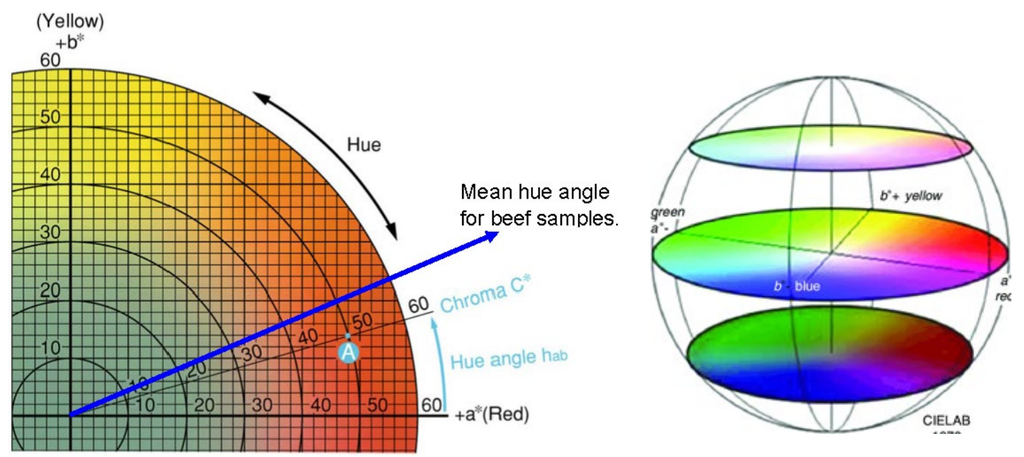

**Mean, standard deviation (S.D.) and coefficient of variation (C.V.) of the 18 variables**

|  | Mean | S.D. | c.v. |
| --- | --- | --- | --- |
| pH | 5.50 | 0.18 | 3.27 |
| Water (W),% | 75.17 | 0.64 | 0.90 |
| Protein (P),% | 22.20 | 0.85 | 3.82 |
| Ether extract (E),% | 0.58 | 0.45 | 77.59 |
| Hydroxyproline (Hy), ftg/g | 529.66 | 181.25 | 34.22 |
| Collagen solubility (Cs),% | 11.46 | 3.24 | 28.27 |
| Lightness (L) | 35.39 | 2.70 | 7.65 |
| Hue (H) | 23.52 | 4.15 | 17.72 |
| Drip losses (DI),% | 2.53 | 0.82 | 32.41 |
| Cooking losses (Cl),% | 30.84 | 3.10 | 10.05 |
| Warner-Bratzler shear (WB), kg | 8.27 | 2.86 | 34.58 |
| Appearance (A) | 6.20 | 0.78 | 12.58 |
| Easer of sinking (Te) | 6.44 | 0.69 | 10.71 |
| Friability (Tl) | 6.19 | 0.68 | 10.99 |
| Residue (Tr) | 5.98 | 0.70 | 11.71 |
| Initial Juiciness (Ji) | 5.92 | 0.64 | 10.81 |
| Sustained juiciness (Js) | 5.60 | 0.64 | 11.43 |
| Overall acceptability (Oa) | 6.13 | 0.70 | 11.42 |

*The Sensory parameters (Appearance to Overall acceptability) are judged on a 8-point structured scale (1 = minimum score ; 8 = maximum score)*

Mean $\pm$ two times the standard deviation for the hue angle corresponds roughly to the interval 15.22* - 31.82*.

```r
Beef <- data.frame("pH" = c(1,rep(0,17)),
                   "Water" = c(0.09,1,rep(0,16)),
                   "Protein"  = c(0.28,-0.4,1,rep(0,15)),
                   "EtherExt" = c(-0.28,-0.16,-0.56,1,rep(0,14)),
                   "Hydroxy" = c(-0.33,-0.08,-0.55,0.59,1,rep(0,13)),
                   "CollaSol" = c(-0.08,-0.01,-0.03,0.05,0.16,1,rep(0,12)),
                   "Lightn" = c(-0.02,0.03,0.34,-0.31,-0.48,-0.02,1,rep(0,11)),
                   "Hue" = c(-0.33,-0.23,-0.47,0.4,0.62,-0.03,-0.21,1,rep(0,10)),
                   "DripLoss" = c(0.01,0.18,-0.07,0.08,-0.12,-0.1,0.25,-0.13,1,rep(0,9)),
                   "CookLoss" = c(-0.38,0.15,-0.64,0.44,0.66,-0.01,-0.45,0.65,0.03,1,rep(0,8)),
                   "WBshear" = c(-0.26,-0.01,-0.63,0.42,0.72,-0.03,-0.55,0.67,-0.11,0.73,1,rep(0,7)),
                   "Appear" = c(0.1,-0.003,0.25,-0.42,-0.33,-0.19,0.35,0.07,0.02,-0.18,-0.28,1,rep(0,6)),
                   "EaseSink" = c(0.17,-0.16,0.27,-0.11,-0.26,0.01,0.19,-0.19,-0.02,-0.36,-0.38,0.24,1,rep(0,5)),
                   "Friabil" = c(0.1,-0.17,0.2,-0.09,-0.22,0.06,0.19,-0.1,-0.03,-0.31,-0.32,0.27,0.93,1,rep(0,4)),
                   "Residue"  = c(0.08,-0.19,0.23,-0.13,-0.24,-0.02,0.2,-0.1,-0.02,-0.32,-0.33,0.33,0.91,0.94,1,rep(0,3)),
                   "InJuice" = c(0.08,-0.08,0.03,-0.004,-0.05,0.05,-0.06,-0.03,-0.13,-0.12,-0.1,0.16,0.69,0.72,0.72,1,rep(0,2)),
                   "SusJuice" = c(0.01,-0.09,-0.004,-0.01,-0.02,0.03,-0.02,0.08,-0.15,-0.07,-0.03,0.24,0.66,0.7,0.7,0.93,1,rep(0,1)),
                   "OvAcc" = c(0.13,-0.13,0.21,-0.09,-0.22,0.07,0.22,-0.14,-0.01,-0.34,-0.37,0.31,0.92,0.92,0.91,0.8,0.79,1)
)
Beef = Beef + t(Beef) - diag(1,18,18)
```

**Canonical Correlation Analysis on Beef Characterization**

We consider the data from Exercise 7.3 and do now want to analyze the relation between the panel assessments and the physical/chemical measurements on the meat by means of Canonical Correlation Analyses of the data. A sample program for this is:

```r
## Computing Canonical correlations and Eigenvalues.

Exx = as.matrix(Beef[1:11,1:11])
Eyx = as.matrix(Beef[12:18,1:11])
Exy = as.matrix(Beef[1:11,12:18])
Eyy = as.matrix(Beef[12:18,12:18])
invExx = solve(Exx)
invEyy = solve(Eyy)

#canonical correlation:
Cancorr = geigen(Eyx%*%invExx%*%Exy,Eyy,symmetric = TRUE)
values = sort(Cancorr$values,decreasing = TRUE)

#E is the residual variation after having predicted Y by means of X
H = Eyx%*%invExx%*%Exy
E = Eyy - Eyx%*%invExx%*%Exy
invE = solve(E)
Ev <- eigen(invE%*%H)
var = Ev$values
# Eigenvalues, Proportion and Cumulative proportion of Variance:
varPC <- var/sum(var)
cumu = c(1:7)
for (i in 1:7){
  cumu[i] = sum(varPC[1:i])
}
results <- data.frame("CanCor" = sqrt(values),"Squared CanCor" = values,"eigenvalues"=var,"proportion"=varPC,
                      "cumulative" = cumu)
```

```r
## Calculating p-values using F-approximations with Wilks test:
n = 79
p = length(Exx[,1])
q = length(Eyy[,1])

HypTest <- p.asym(results$CanCor,n,p,q,tstat="Wilks")
print("Table with information about the Canonical Correlations similar to the output in SAS:")
results_all <- data.frame(results,HypTest)
results_all
```

```
## Wilks' Lambda, using F-approximation (Rao's F):
##               stat    approx df1      df2    p.value
## 1 to 7:  0.2319646 1.3375749  77 372.9807 0.04166877
## 2 to 7:  0.4230666 0.9810705  60 329.8928 0.51995711
## 3 to 7:  0.6801983 0.5696448  45 284.9171 0.98797220
## 4 to 7:  0.8126073 0.4297982  32 237.6155 0.99724136
## 5 to 7:  0.8922633 0.3609966  21 187.1950 0.99592163
## 6 to 7:  0.9589010 0.2332596  12 132.0000 0.99637196
## 7 to 7:  0.9853265 0.1995531   5  67.0000 0.96156219
```

```
## [1] "Table with information about the Canonical Correlations similar to the output in SAS:"
```

```
##      CanCor Squared.CanCor eigenvalues  proportion cumulative    id      stat
## 1 0.6720912     0.45170663  0.82384114 0.447388814  0.4473888 Wilks 0.2319646
## 2 0.6148370     0.37802455  0.60778051 0.330056594  0.7774454 Wilks 0.4230666
## 3 0.4036625     0.16294345  0.19466241 0.105711869  0.8831573 Wilks 0.6801983
## 4 0.2987878     0.08927414  0.09802526 0.053232840  0.9363901 Wilks 0.8126073
## 5 0.2636168     0.06949381  0.07468388 0.040557253  0.9769474 Wilks 0.8922633
## 6 0.1637651     0.02681901  0.02755809 0.014965481  0.9919129 Wilks 0.9589010
## 7 0.1211342     0.01467351  0.01489202 0.008087147  1.0000000 Wilks 0.9853265
##      approx df1      df2    p.value
## 1 1.3375749  77 372.9807 0.04166877
## 2 0.9810705  60 329.8928 0.51995711
## 3 0.5696448  45 284.9171 0.98797220
## 4 0.4297982  32 237.6155 0.99724136
## 5 0.3609966  21 187.1950 0.99592163
## 6 0.2332596  12 132.0000 0.99637196
## 7 0.1995531   5  67.0000 0.96156219
```

**1. How many Canonical Correlation Coefficients are significantly different from 0?**

We get the p-values directly in the output above, and see that only one is significantly different from 0. For similarity to the SAS output, the Wilk Lambda `tstat` is used for the test.

**2. Give a verbal description of the definition of the first 2 canonical variables for the panel data and for the physical/chemical measurements!**

```r
# Correlations between the Panel variables (Eyy) and their Canonical variables
CorPanel = Eyy%*%Cancorr$vectors

#corresponding standardized canonical coefficients / correlations:
Coefficients = data.frame("Variables" = names(Beef)[12:18],
                          "CoefV1" = -1*round(Cancorr$vectors[,7],1),
                          "CoefV2" = -1*round(Cancorr$vectors[,6],1),
                          "CorrV1" = -1*round(CorPanel[,7],1),
                          "CorrV2" = -1*round(CorPanel[,6],1),
                          "Diff.between.Sq.Corr." = round(CorPanel[,7],1)^2-round(CorPanel[,6],1)^2)

print("Standardized Canonical Coefficients for the Panel Variables and Correlations Between the Panel Variables and Their Canonical Variables:")
Coefficients
```

```
## [1] "Standardized Canonical Coefficients for the Panel Variables and Correlations Between the Panel Variables and Their Canonical Variables:"
```

```
##    Variables CoefV1 CoefV2 CorrV1 CorrV2 Diff.between.Sq.Corr.
## 12    Appear    0.7   -0.6    0.8   -0.5                  0.39
## 13  EaseSink    0.1    0.1    0.5    0.3                  0.16
## 14   Friabil   -0.2   -0.3    0.5    0.2                  0.21
## 15   Residue    0.1   -0.7    0.5    0.2                  0.21
## 16   InJuice   -0.2    0.6    0.1    0.1                  0.00
## 17  SusJuice   -0.6   -1.5    0.1   -0.1                  0.00
## 18     OvAcc    0.9    2.0    0.5    0.3                  0.16
```

**Note: For consistency of description of the canonical variables between the output in SAS and in R, some canonical coefficients and correlations are multiplied by -1 to have the same explanations.**

We consider a meat sample with a high value of the canonical variable V1 for the Panel variables The coefficients for computing V1 show that this may be due to predominantly high scores on Appearance and Overall Acceptability and to a lesser extent low values on Juiciness. The tenderness parameters Ease of Sinking, Friability, and Residue seem to be of minor importance. However, since the Panel variables are strongly correlated, the values of those may not vary freely. E.g. we see that the correlation between the two Juiciness variables is 0.93 telling us that the Initial and the Sustained Juiciness show a very similar behavior. Therefore, we must also consult the correlations between the Panel variables and their canonical variables in interpreting those. From the correlations, we see that all Panel variables except the two Juiciness variables have a correlation of 0.5 or larger with the first canonical variable. The correlations with the Juiciness parameters are negligible. On the other hand, a low score is obtained for meat where all or most quality parameters are below average. **As a conclusion we might say that the first canonical variable of the Panel variables measure the perceived general quality of a meat sample. Juiciness is of little importance here.**

The coefficients indicate that a high value on canonical variable V2 corresponds to high scores on Overall Acceptability and Initial Juiciness and a low score on Residue on one side, and low scores on Appearance and Sustained Juiciness on the other side. Considering the strong correlations, we modify this statement somewhat. The numerically largest correlation is the negative correlation with the Appearence (-0.5). Furthermore, the correlations with the other Panel variables are with one exception positive. Therefore, a high V2 variable corresponds to a meat sample with a low appearance score and positive scores for all but one of the other perceived quality parameters. **One might say that the meat sample tastes better than it looks.**A low score is obtained for a piece of meat with perceive quality below average, but attractive appearance.

```r
#for Phys/Chem variables:
Cancorr2 = geigen(Exy%*%invEyy%*%Eyx,Exx,symmetric = TRUE)

# Correlations between the Phys/Chem variables (Exx) and their Canonical variables
CorPhysChem = Exx%*%Cancorr2$vectors

#corresponding standardized canonical coefficients / correlations:
Coefficients2 = data.frame("Variables" = names(Beef)[1:11],
                           "CoefW1" = -1*round(Cancorr2$vectors[,11],1),
                           "CoefW2" = round(Cancorr2$vectors[,10],1),
                           "CorrW1" = -1*round(CorPhysChem[,11],1),
                           "CorrW2" = round(CorPhysChem[,10],1),
                           "Diff.between.Sq.Corr." = round(CorPhysChem[,11],1)^2-round(CorPhysChem[,10],1)^2)
print("Standardized Canonical Coefficients for the Phys/Chem Variables and Correlations Between the Phys/Chem Variables and Their Canonical Variables")
Coefficients2
```

```
## [1] "Standardized Canonical Coefficients for the Phys/Chem Variables and Correlations Between the Phys/Chem Variables and Their Canonical Variables"
```

```
##    Variables CoefW1 CoefW2 CorrW1 CorrW2 Diff.between.Sq.Corr.
## 1         pH    0.1    0.2    0.3    0.3                  0.00
## 2      Water   -0.1   -0.1   -0.1    0.0                  0.01
## 3    Protein   -0.1    0.0    0.6    0.2                  0.32
## 4   EtherExt   -0.4    0.6   -0.6    0.3                  0.27
## 5    Hydroxy    0.0    0.5   -0.6   -0.1                  0.35
## 6   CollaSol   -0.1    0.3   -0.2    0.4                 -0.12
## 7     Lightn    0.2    0.0    0.7    0.1                  0.48
## 8        Hue    0.6   -0.6   -0.2   -0.6                 -0.32
## 9   DripLoss    0.2    0.1    0.2    0.2                  0.00
## 10  CookLoss   -0.1   -0.1   -0.6   -0.4                  0.20
## 11   WBshear   -0.8   -0.5   -0.8   -0.5                  0.39
```

**Note: For consistency of description of the canonical variables between the output in SAS and in R, some canonical coefficients and correlations are multiplied by -1 to have the same explanations.**

We look at the coefficients for computing the canonical variables of the physical/chemical measurements and at the correlations between the physical/chemical measurements and the canonical variables. We see that a high value of W1 corresponds to high protein content, low fat content (from the EtherExt value), low amount of connective tissue (hydroxyproline), large lightness value, little cooking loss and good tenderness (low WBshear value). This combination of the physical and chemical parameters corresponds well to what **one would expect from a high quality piece of meat**. A low value - on the other side - corresponds to a piece of meat with low protein content, with a lot of fat and connective tissue and very dark color. Furthermore, the meat looses weight in cooking and is tough, all indications of low quality.

For a piece of meat with a large value of W2, we get the following interpretations. For the second canonical variable, the numerically largest correlation with one of the physical/chemical parameters is the negative correlation with the Hue. A high value of W2 will thus correspond to a meat sample with a low value of hue, i.e. a sample that is redder. A low value of W2 will correspond to a more yellowish color. The squared correlation between Hue and W2 is larger than the squared correlation between Hue and W1. The only other variable with an increased (squared) correlation by going from W1 to W2 is Collagen Solubility. The largest change in squared correlations from W1 to W2 is the jump from 0.72 to 0.12 for Lightness meaning that lightness is only of minor importance as regards interpretation of W2 compared to interpretation of W1. The relations to Protein content, to amount of Connective Tissue (Hydroxyproline), to Lightness, to Cooking Loss and to Tenderness (WBshear) have the same sign as before, but the correlations are numerically smaller. A high value of W2 will thus correspond to a meat sample with a visual appearance tending to be redder. Furthermore, W2 is less correlated with the other physical/chemical quality variables, but the values of those corresponding to better quality will still in general be accompanied by high values of W2. In other words, a high value of W2 corresponds to a sample with **a visual appearance that is redder than that of a ‘high W1 sample’ and with a moderate tendency to have other physical/chemical values that correspond to a quality above average. In particular, the higher heat solubility of collagen is of some importance, which in non-technical language might be expressed that cooking tenderizes the meat better**.

**3. What are the plots showing?**

Correlation between the original variables of the sensory panel (VAR Variables) and (**W1,W2**) the Canonical Variables of the physical/chemical variables (WITH Variables):

```r
#Correlations between the Panel Variables and the Canonical Variables of the Phys/Chem Variables
Panel_PhysChem = Eyx%*%Cancorr2$vectors

CorPan_CanPhysChem = data.frame("Variables"=names(Beef)[12:18],
                                "W1" = -1*round(Panel_PhysChem[,11],2),
                                "W2" = round(Panel_PhysChem[,10],2),
                                "Corr" = round(sqrt(round(Panel_PhysChem[,11],1)^2+round(Panel_PhysChem[,10],1)^2),2))
CorPan_CanPhysChem
```

```
##    Variables   W1    W2 Corr
## 12    Appear 0.56 -0.30 0.67
## 13  EaseSink 0.33  0.22 0.36
## 14   Friabil 0.31  0.15 0.36
## 15   Residue 0.34  0.10 0.32
## 16   InJuice 0.05  0.08 0.14
## 17  SusJuice 0.06 -0.04 0.10
## 18     OvAcc 0.34  0.21 0.36
```

Correlation between the original Physical/Chemical variables (WITH Variables) and (**V1,V2**), the Canonical Variables of the sensory panel variables (VAR Variables):

```r
#Correlations between the Phys/Chem Variables and the Canonical Variables of the Panel Variables
PhysChem_Panel = Exy%*%Cancorr$vectors
CorPhysChem_CanPan = data.frame("Variables"=names(Beef)[1:11],
                              "V1" = -1*round(PhysChem_Panel[,7],2),
                              "V2" = -1*round(PhysChem_Panel[,6],2),
                              "Corr" = round(sqrt(round(PhysChem_Panel[,7],1)^2+round(PhysChem_Panel[,6],1)^2),2))
CorPhysChem_CanPan
```

```
##    Variables    V1    V2 Corr
## 1         pH  0.17  0.17 0.28
## 2      Water -0.05 -0.01 0.10
## 3    Protein  0.38  0.11 0.41
## 4   EtherExt -0.38  0.18 0.45
## 5    Hydroxy -0.43 -0.05 0.40
## 6   CollaSol -0.11  0.23 0.22
## 7     Lightn  0.48  0.05 0.51
## 8        Hue -0.13 -0.37 0.41
## 9   DripLoss  0.13  0.13 0.14
## 10  CookLoss -0.39 -0.27 0.50
## 11   WBshear -0.52 -0.31 0.58
```

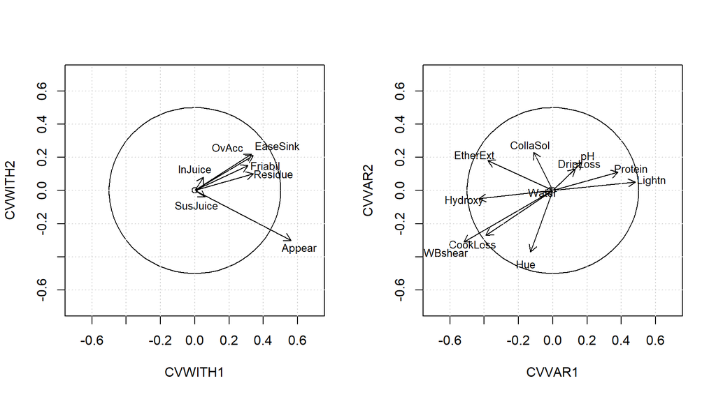

```r
par(mfrow=c(1,2))
TextMove = matrix(c(0.05,0.15,0.1,0.12,-0.05,-0.05,-0.15,
                   -0.05,0.05,0,0,0.05,-0.05,0.05),ncol=2)

# plotting the correlations:
circle = seq(-3.2,3.2,by=0.1)

plot(0,0,xlim = c(-0.7,0.7),ylim = c(-0.7,0.7),xlab = "CVWITH1",
     ylab = "CVWITH2")
points(0.5*cos(circle),0.5*sin(circle),type='l')
arrows(c(rep(0,7)),c(rep(0,7)),CorPan_CanPhysChem[,2],CorPan_CanPhysChem[,3],length = 0.1)
text(CorPan_CanPhysChem[,2]+TextMove[,1],CorPan_CanPhysChem[,3]+TextMove[,2],CorPan_CanPhysChem[,1],cex=0.8)
grid()


plot(0,0,xlim = c(-0.7,0.7),ylim = c(-0.7,0.7),xlab = "CVVAR1",
     ylab = "CVVAR2")
points(0.5*cos(circle),0.5*sin(circle),type='l')
arrows(c(rep(0,7)),c(rep(0,7)),CorPhysChem_CanPan[,2],CorPhysChem_CanPan[,3],length = 0.1)
text(CorPhysChem_CanPan[,2]*1.2,CorPhysChem_CanPan[,3]*1.2,CorPhysChem_CanPan[,1],cex=0.8)
grid()
```

The correlation plot to the left shows the predictions of the panel variables based on canonical variables of the physical/chemical variables. One variable, Appear, stands out. It is well correlated with W1 and the multiple correlation with (W1, W2) is 0.67, considerably larger than any other! The juiciness variables are not well predicted, and the remaining 4 variables are behaving very similarly, basically forming one ‘factor’.

The plot to the right shows that Lightness, Cooking loss and WBshear are the physical/chemical variables best predicted by the Sensory canonical variables.

**4. Describe the relationship between the panel assessments and the physical/chemical measurements!**

The most informative statement is that the linear combinations

$$\begin{align}V_1 = & 0.7 \times Appear + 0.1 \times EaseSink - 0.2
\times Friabil + 0.1 \times Residue \\
& - 0.2 \times Injuice - 0.6 \times Susjuice + 0.9 \times
OvAcc\end{align}$$

and

$$\begin{align}W_1 = & 0.1 \times pH - 0.1 \times Water - 0.1 \times
Protein - 0.4 \times EtherExt + 0.0 \times Hydroxy \\
& - 0.1 \times CollaSol + 0.2 \times Lightn + 0.6 \times Hue + 0.2
\times DripLoss - 0.1 \times CookLoss \\
& - 0.8 \times WBshear\end{align}$$

are strongly correlated with
$$\rho(V_1,W_1) = 0.6721$$
Furthermore, the variables

$$\begin{align}V_2 = & - 0.6 \times Appear + 0.1 \times EaseSink - 0.3
\times Friabil - 0.7 \times Residue \\
& + 0.6 \times Injuice - 1.5 \times Susjuice + 2.0 \times
OvAcc\end{align}$$

and

$$\begin{align}W_2 = & 0.2 \times pH - 0.1 \times Water - 0.0 \times
Protein + 0.6 \times EtherExt + 0.5 \times Hydroxy \\
& + 0.3 \times CollaSol + 0.0 \times Lightn - 0.6 \times Hue + 0.1
\times DripLoss - 0.1 \times CookLoss \\
& - 0.5 \times WBshear\end{align}$$

are uncorrelated with $V_1$ and $W_1$. Their mutual correlation is

$$\rho(V_2,W_2) = 0.6148$$

We have determined that high values of **W1** was indicative of a high quality piece of meat, and that high values of **W2** indicated redder meat while still having a quality above average. Inspecting the left plot, we see that **W1** is highly correlated with Appear, and to a lesser degree OvAcc, EaseSink, Friabil, and Residue. That is: a high quality piece of meat is something that looks good to the sensory panel and that is easy to sink and fry. For **W2** the pattern is quite similar except for appearance. This fits well with our interpretation of **W2**.

For the sensory panel, we had that **V1** points to the perceived quality, and large values of **V2** indicates a piece of meat that was better than it looked. The quality is correlated positively with Ligthn and Protein but is negatively correlated with WBshear, Hydroxy, EtherExt, and cookloss. That means that a piece of meat with a perceived high quality, will be light and protein rich, while having a low toughness, low amount of connective tissue, low amount of fat and little cook loss. For a piece of meat that looks worse than it is, the **V2** value is mainly determined by the Hue (which is not surprising), and the meat may contain some fat (positive EtherExt).

In conclusion we have found that as well the sensory panel variables as the physical/chemical variables relates well to a quality concept for beef. I we want to predict the quality as expressed by the first canonical variable of the sensory panel data using the canonical variable of the physical/chemical data around 45% of the variability is explained!

## References

1. R. Boccard, L. Butcher, E. Casteels, E. Cosentino, E. Dransfield, D.E. Hood, R.L. Joseph, D.B. MacDougall, D.N. Rhodes, T. Schon, B.J. Tinbergen, and C. Touraille (1981): Procedures for measuringMeat Quality Characteristics in Beef production Experiments. Report of a Working Group in the Commission of the European Communities (CEC) Beef Production Programme. Livestock Production Science, vol. 8, pp. 385-397.
2. G. Destefanis, M.T. Barge, A. Brugiapaglia, and S. Tassone (2000): The use of principal component analysis (PCA) to characterize beef. Meat Science 56 (2000), pp 255-259.
3. R. Warner . (2014): Measurement of Meat Quality: Measurements of Water-holding Capacity and Color - Objective and Subjective. In: Carrick Devine & Michael Dikeman, editors-in-chief. Encyclopedia of Meat Sciences 2e, Vol. 2, Oxford: Elsevier; pp. 164-171 (http://www.zevendesign.com/category/glossary/browse-C/)
4. R.E. Wrolstad and D.E. Smith. (2010) Color Analysis. In: Food Analysis, Springer, Boston, MA. (https://doi-org.proxy.findit.cvt.dk/10.1007/978-1-4419-1478-1_32)

### Annex on correlation plot.

**Theorem.** Let the n+1 dimensional random variable $\begin{bmatrix} Y & X^T \end{bmatrix}^T$ have mean and dispersion equal to

$E \begin{bmatrix} Y \\ \boldsymbol{X} \end{bmatrix} = \begin{bmatrix} 0 \\ \boldsymbol{0} \end{bmatrix}$  
and  
$D\begin{bmatrix} Y \\ \boldsymbol{X} \end{bmatrix} = \boldsymbol{\Sigma}_n = \begin{bmatrix} 1 & \boldsymbol{\rho}_n^T \\ \boldsymbol{\rho}_n & \boldsymbol{I}_n \end{bmatrix}$

Then the squared, multiple correlation coefficient between Y and **X** is

$\rho_{Y|X}^2 = \boldsymbol{\rho}_n^T\boldsymbol{\rho}_n = \rho_1^2 + \cdots + \rho_n^2$.

The best predictor for Y is the regression

$\hat{Y} = E(Y|\boldsymbol{X}) = \boldsymbol{\rho}_n^T \boldsymbol{X} = \rho_1 X_1 + \cdots + \rho_n X_n$.

and we have

$\rho_{Y\hat{Y}}^2 = \rho_{Y|\boldsymbol{X}}^2$

**Proof.** From Theorem 1.42 we get

$\rho_{Y|\boldsymbol{X}}^2 = 1 - \frac{\det \boldsymbol{\Sigma}_n}{1 \times \det\boldsymbol{I}_n}$

and the result follows immediately.

**Example.** Correlation plot

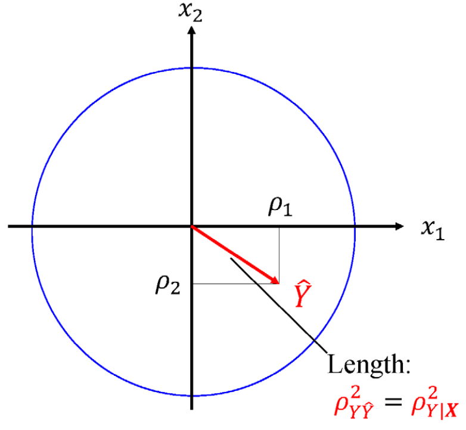

**Lemma.** Let

$\boldsymbol{\Sigma}_n = \begin{bmatrix} 1 & \boldsymbol{\rho}_n^T \\ \boldsymbol{\rho}_n & \boldsymbol{I}_n \end{bmatrix}$  
where  
$\boldsymbol{\rho}_n^T = \begin{bmatrix}\rho_1 & \cdots & \rho_n \end{bmatrix}$

Then

$\det\boldsymbol{\Sigma}_n = 1 - \boldsymbol{\rho}_n^T\boldsymbol{\rho}_n$,

and $\boldsymbol{\Sigma}_n$ is a dispersion matrix iff $\boldsymbol{\rho}_n^T\boldsymbol{\rho}_n = \rho_1^2 + \cdots + \rho_n^2 \leq 1$.

**Proof.** Follows directly from Theorem A7.